# Summary of ICD-9 codes

Mengbing Li

January 18, 2019

The data file used in this summary is `Box Sync\OptumInsight_DataManagement\data_freeze\20190110\diagInpatient_long.csv`. For a description of the data file, go to `Box Sync\OptumInsight_DataManagement\data_freeze\20190110\DataDescription.md`.

For an overview of the data, here is the number of unique ICD-9 codes in our cohort data, regardless of which level of the code is in.

```r
diagInpatient <- fread("../diagInpatient_long.csv")
```

```
##
Read 32.1% of 1370333 rows
Read 87.6% of 1370333 rows
Read 1370333 rows and 12 (of 12) columns from 0.164 GB file in 00:00:04
```

```r
# extract 3-digit ICD-9 codes
source("../functions/icd9_hierarchy.R")

diagInpatient$icd9_3digits <- icd9_3digits(diagInpatient, icd9_raw)
diagInpatient$icd9_4digits <- icd9_4digits(diagInpatient, icd9_raw)
diagInpatient$icd9_5digits <- icd9_5digits(diagInpatient, icd9_raw)

length(unique(diagInpatient$icd9_raw))
```

```
## [1] 6473
```

We look at the length of the ICD-9 codes.

```r
test <- nchar(trimws(unique(diagInpatient$icd9_raw)))
table(nchar(unique(diagInpatient$icd9_raw)))
```

```
##
##    1    3    4    5
##    3  128 2821 3521
```

## 1. 3-digit ICD-9 codes

Since I am considering using the 3-digit ICD-9 codes, I do a summary specifically for this level.

Count the number of patients that were admitted at least once, and number of unique inpatient 3-digit ICD-9 codes

```r
# count the number of times each ICD-9 code appears in each patient
# and store the counts in a sparse matrix
source("../functions/generateCountMatrix.R")
diagInpatientCount <- generateCountMatrix(data = diagInpatient, x = "icd9_3digits", sparse = TRUE)

dim(diagInpatientCount)
```

```
## [1] 11669  1217
```

Count the number of unique ICD-9 codes each patient has between index VTE date and 2015-09-30.

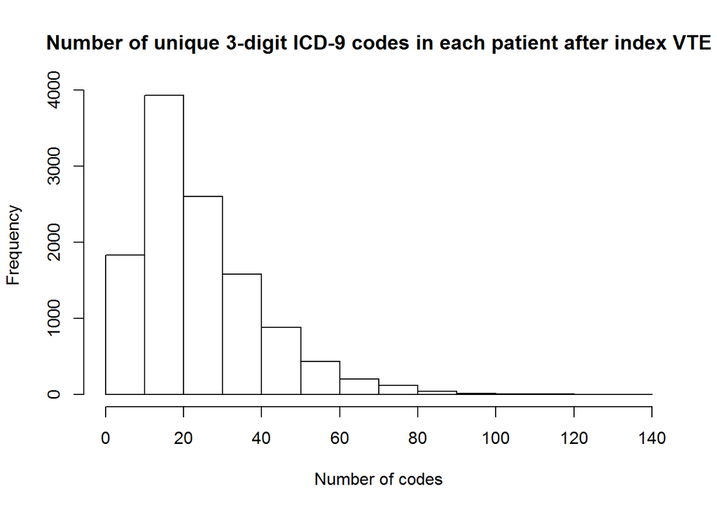

```r
NUniqueCodeByPatient <- apply(diagInpatientCount, 1, function(x) sum(x>0))

hist(NUniqueCodeByPatient,
     main = "Number of unique 3-digit ICD-9 codes in each patient after index VTE",
     xlab = "Number of codes")
```

The number of 3-digit ICD-9 codes for a patient on each day.

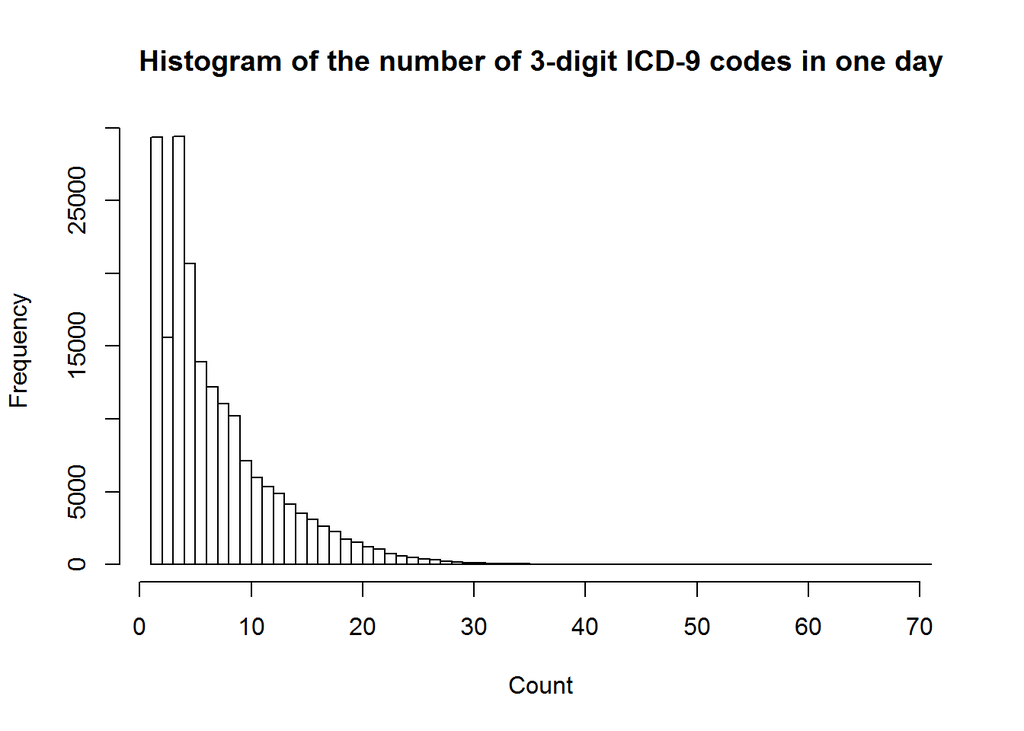

```r
diagInpatientCountByDay <- c(table(paste(diagInpatient$patid, diagInpatient$fst_dt)))

hist(diagInpatientCountByDay,
     main = "Histogram of the number of 3-digit ICD-9 codes in one day",
     xlab = "Count",
     breaks = seq(1, max(diagInpatientCountByDay)+1))
```

```r
summary(diagInpatientCountByDay)
```

```
##    Min. 1st Qu.  Median    Mean 3rd Qu.    Max.
##   1.000   4.000   6.000   7.205  10.000  70.000
```

A diagnostic code may be recorded multiple times in a day simply because the patient went encountered doctors at different places of services such as ambulance and inpatient hospital. We suspect that the repetitive diagnostic codes provide little information about the disease progress of a patient or the relationship between diseases. Therefore we also look at the number of Unique 3-digit ICD-9 codes for a patient on each day. The uniqueness is identified by the combination of patid, fst_dt, and ICD-9 code.

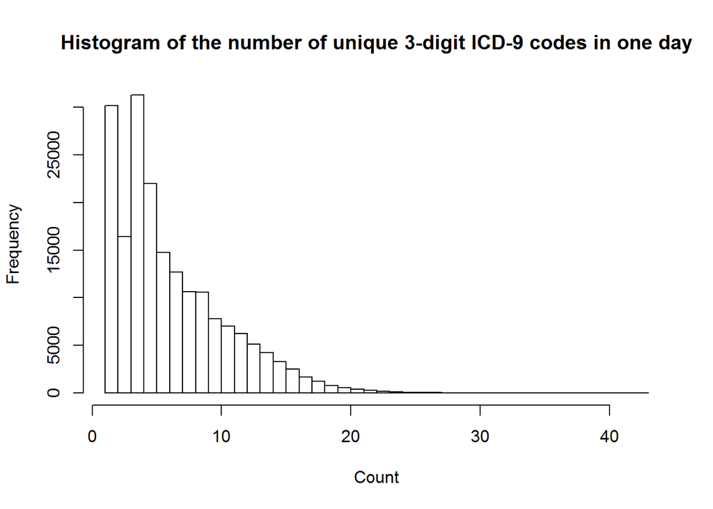

```r
diagInpatientUniqueInADay <- diagInpatient[!duplicated(diagInpatient[,.(patid, fst_dt, icd9_raw)]),]

diagInpatientUniqueInADay.Count <-
  c(table(paste(diagInpatientUniqueInADay$patid, diagInpatientUniqueInADay$fst_dt)))

hist(diagInpatientUniqueInADay.Count,
     main = "Histogram of the number of unique 3-digit ICD-9 codes in one day",
     xlab = "Count",
     # xlim = range(1, max(diagInpatientUniqueInADay.Count)),
     breaks = seq(1, max(diagInpatientUniqueInADay.Count)+1))
```

```r
summary(diagInpatientUniqueInADay.Count)
```

```
##    Min. 1st Qu.  Median    Mean 3rd Qu.    Max.
##   1.000   4.000   5.000   6.512   9.000  42.000
```

## 2. Summarize the tree-structure of ICD-9 codes

Instead of looking at the ICD-9 codes from the original claims data, we strip the codes to look at different levels. We strip the 4-digit and 5-digit ICD-9 codes into lower levels, and count the number of unique ICD-9 codes at each level.

```r
apply(diagInpatient[, c("icd9_3digits", "icd9_4digits", "icd9_5digits")], 2, function(x) length(unique(x)))
```

```
## icd9_3digits icd9_4digits icd9_5digits
##         1217         4131         3372
```

Now we would like to obtain a description of the ICD-9 trees.

```r
GetNodeLength <- function(x){
  length(unique(na.omit(x)))
}

icd9_3digits_unique <- unique(diagInpatient$icd9_3digits)
icd9Tree_NodeCounts <- NULL
for(j in icd9_3digits_unique){
  subdata <- unique(diagInpatient[icd9_3digits==j, .(icd9_3digits, icd9_4digits, icd9_5digits)])
  # change empty cells to NA
  for (j in colnames(subdata))
    set(subdata, j = j, value = gsub("^$|-|^0{3,5}$", NA, subdata[[j]]))

  # count the number of nodes at each level
  subNodeCount <- c(1, GetNodeLength(subdata$icd9_4digits), GetNodeLength(subdata$icd9_5digits))
  icd9Tree_NodeCounts <- rbind(icd9Tree_NodeCounts, subNodeCount)
}

icd9Tree_NodeCounts <- data.table( cbind(icd9_3digits_unique, icd9Tree_NodeCounts))
rownames(icd9Tree_NodeCounts) <- 1:nrow(icd9Tree_NodeCounts)
colnames(icd9Tree_NodeCounts) <- c("icd9_3digits", "N_3digit", "N_4digit", "N_5digit")
icd9Tree_NodeCounts[, 2:4] <- lapply(icd9Tree_NodeCounts[, 2:4], as.integer)
```

We look at the size of the trees.

First, the number of nodes in individual trees.

```r
col_set <- c("green", "red", "blue")
pdf("results_TreeSizes.pdf", width=100, height=5)
matplot(icd9Tree_NodeCounts[, 2:4], type="l", lty = "solid", lwd = 0.5, xaxt='n',
        col = col_set, xlab = "ICD-9 codes", ylab = "Counts",
        main = "The number of nodes in individual trees")
axis(1, at=1:nrow(icd9Tree_NodeCounts),
     labels = icd9Tree_NodeCounts$icd9_3digits, cex.axis=0.5, srt=45)
legend("topleft", colnames(icd9Tree_NodeCounts)[2:4], col = col_set,
       cex = 0.8, fill = col_set)
dev.off()
```

Second, the frequency of tree patterns.

```r
# count the number of unique patterns
icd9Tree_UniquePattern <- unique(icd9Tree_NodeCounts[,-1][, patternCount := .N, by = .(N_3digit, N_4digit, N_5digit)])
icd9Tree_UniquePattern <- icd9Tree_UniquePattern[order(N_3digit, N_4digit, N_5digit, patternCount), ]

# transform data from wide to long
icd9Tree_UniquePattern$ID <- 1:nrow(icd9Tree_UniquePattern)
icd9Tree_UniquePattern_long <- melt(icd9Tree_UniquePattern,
                                    id.vars = c("ID", "patternCount"),
                                    measure.vars = c("N_3digit", "N_4digit", "N_5digit"),
                                    value.name = "digits",
                                    variable.name = "count")

pdf("results_TreeSizePatterns.pdf", width=30, height=50)
ggplot(data = icd9Tree_UniquePattern_long,
       aes(y = digits, x = count, group = ID)) +
  geom_line(aes(color = patternCount, size = patternCount)) +
  scale_color_gradient(low = "gray", high = "black") +
  labs(title = "The number of nodes at each level in a ICD-9 tree",
       x = "ICD-9 Tree level", y = "Number of nodes")
dev.off()
```